# Terrorismo Global

Rodrigo

4 de enero de 2017

## Introducción

El objetivo de este análisis es ver la evolución del terrorismo tanto en nuestro país como en nuestro entorno, para poder compararlo con otras latitudes y ver si podemos sacar algunas conclusiones. Los datos han sido obtenidos de Global Terrorism Database (https://www.kaggle.com/START-UMD/gtd) que contiene datos de atentados terroristas desde 1970 a 2015. En este enlace se puede ver la descripción de los datos y la decodificación de http://start.umd.edu/gtd/downloads/Codebook.pdf

Primero vamos a ver el número de ataques terroristas que ha habido en España en el periodo del que tenemos datos.

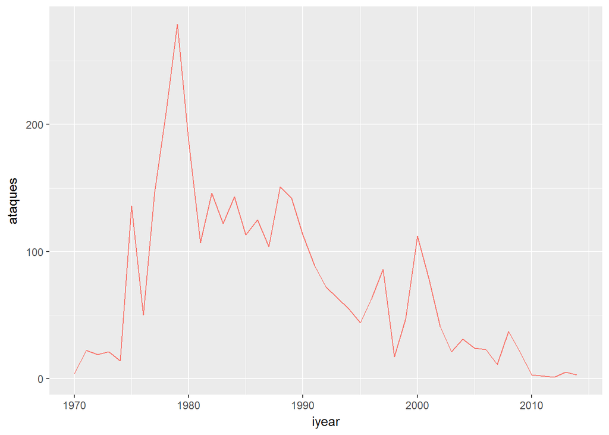

Podemos ver que en los últimos años ha habido un descenso de ataques. Comprobamos si también ha habido un descenso en el número de muertos.

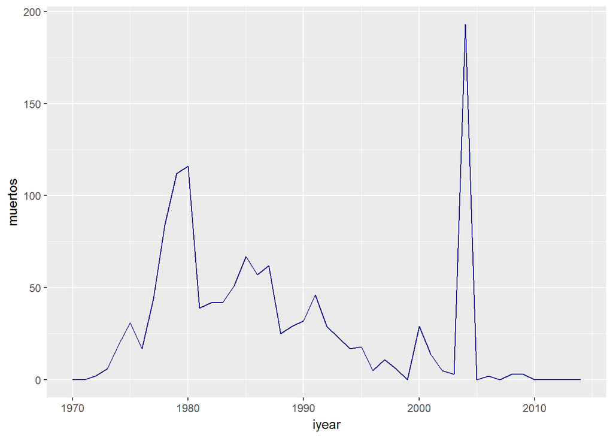

Parece que a excepción de un pico en 2004 (los atentados del 11M en Madrid) también se ha reducido el número de muertos. En principio podríamos pensar que está directamente relacionado con el fin de los actos violentos de ETA, por lo que vamos a ver quién ha cometido Atentados en España. No se muestran todos los grupos terroristas por no llenar la gráfica con muchos datos, sólo se muestran los que más impacto han tenido.

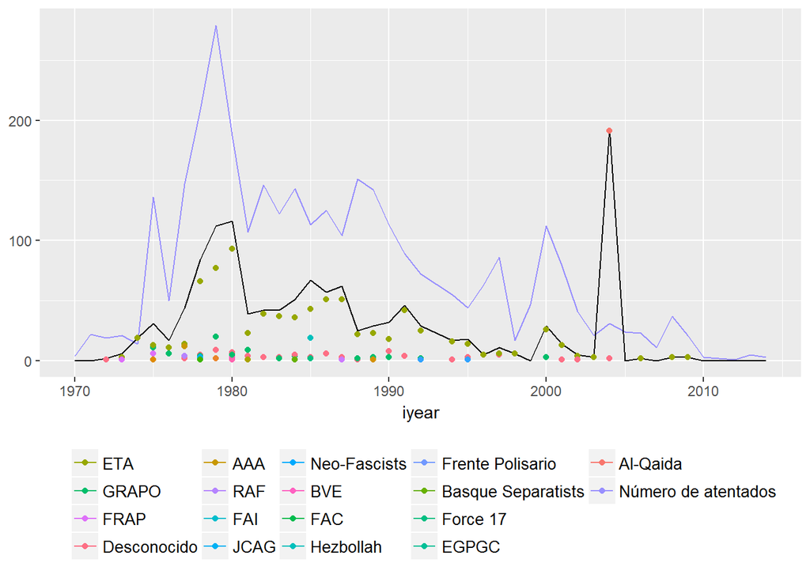

A simple vista el número de muertos en España por terrorismo está muy relacionado con la actividad de ETA. Pero vamos a realizar una coparativa entre las dos variables para poder asegurarnos.

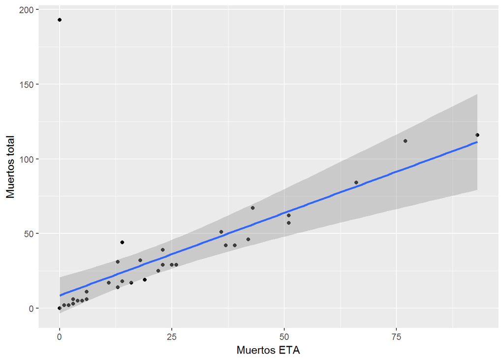

Ahora vamos a comparar los datos de España con Francia, Alemania, Italia y Reino unido.

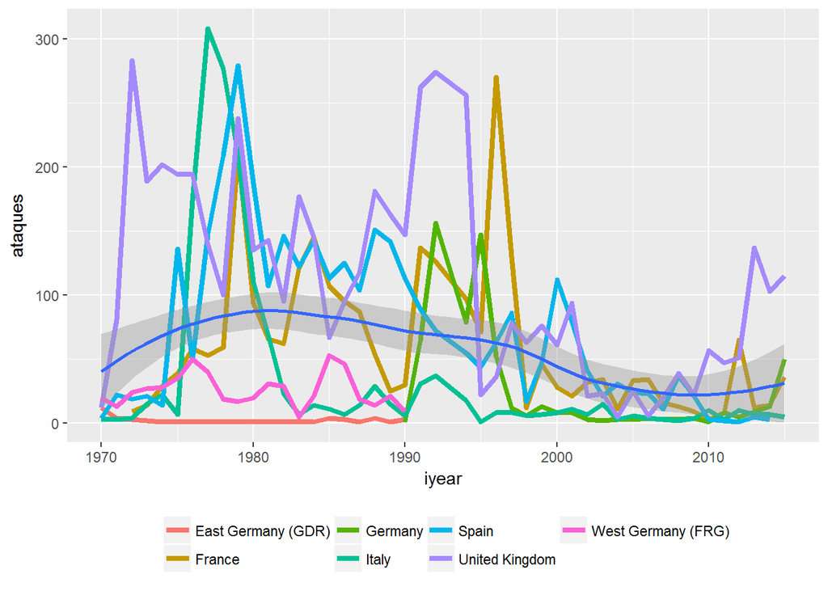

Por lo que podemos observar en nuestro entorno cercano, a finales de los 70 hubo bastante actividad de grupos terroristas para ir reduciéndose progresivamente, hasta llegar al punto mínimo a finales de la década pasada y empezar a ascender en los últimos años.

Vamos a ver si en el número de muertos sucede lo mismo.

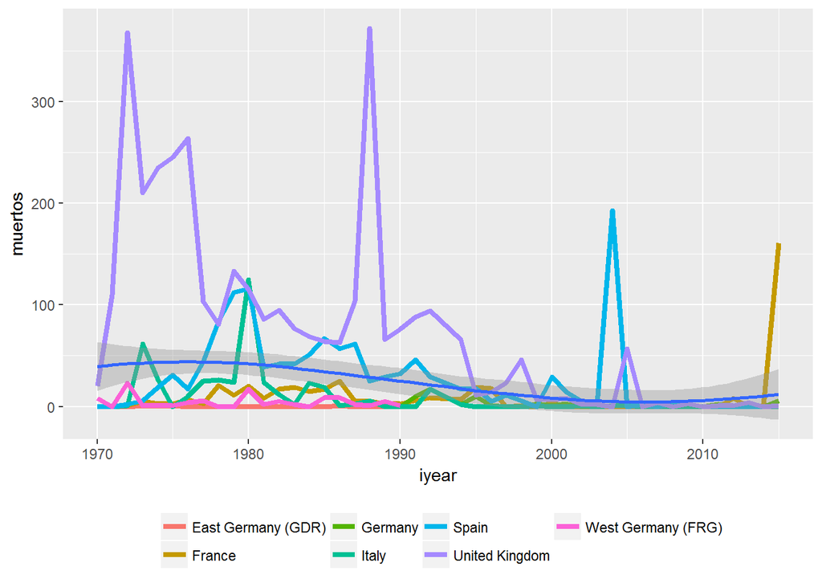

En base a los muertos se podría ver lo mismo que en la gráfica anterior. Tan solo observamos que la tendencia es a ser más plana, habiendo menos diferencia entre los picos y los valles.

Para poder comprobar si para todo nuestro entorno sucede lo mismo, los datos también tienen divisiones por zonas, La zona correspondiente a España (Europa occidental) tienen el siguiente aspecto:

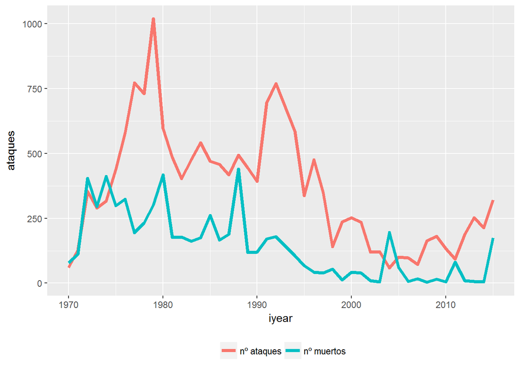

Podemos ver que a nivel general las tendencias son las mismas a nivel europeo ¿y si lo comparamos con el resto del mundo?

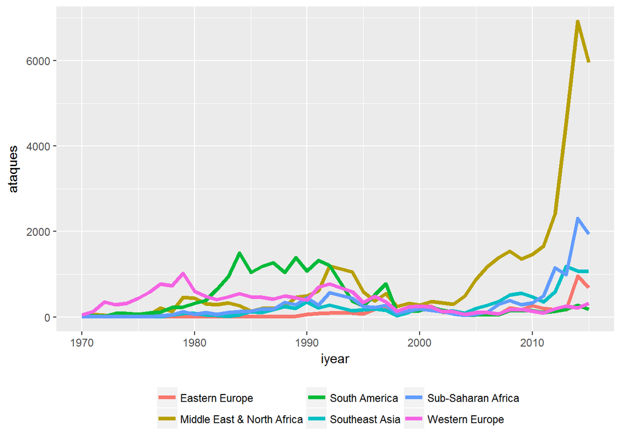

Solo se muestran aquellas zonas en las que ha habido algo reseñable. Se puede ver que en la década de los 70 Europa occidental fue la parte más golpeada por el terrorismo, para ser sustituida a comenzados los 80 por Sudamérica, coincidiendo con la guerra contra la droga que se dio en esa parte del mundo y el surgimiento de grupos guerrilleros y paramilitares (aunque habría que profundizar en los datos y comprobar que esa premisa sea cierta). El relevo de sudamérica lo toma a mediados de los 90 de Oriente medio y Norte de áfrica, aunque rondando el 2000 se tiene una década “más tranquila”, a mediados de la primera década del 2000 se dispara casi de forma exponencial en Oriente medio y Norte de áfrica, además al final de la gráfica y podemos ver la aparición de nuevas zonas (áfrica subsahariana, Europa del este y sudeste asiático) golpeadas por el terrorismo que hasta el momento no habían tenido mucha relevancia.

En cuanto al número de muertos vamos a ver como la gráfica se dispara, dejando en algo casi anecdótico (si solo hacemos caso a los datos) los muertos en Europa occidental.

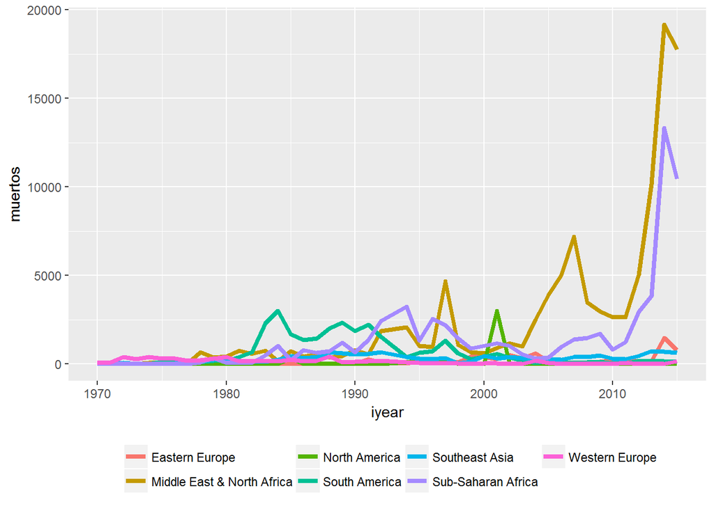

Si vemos el acumulado, podemos ver mas claramente como en los últimos años se ha disparado el número de muertos.

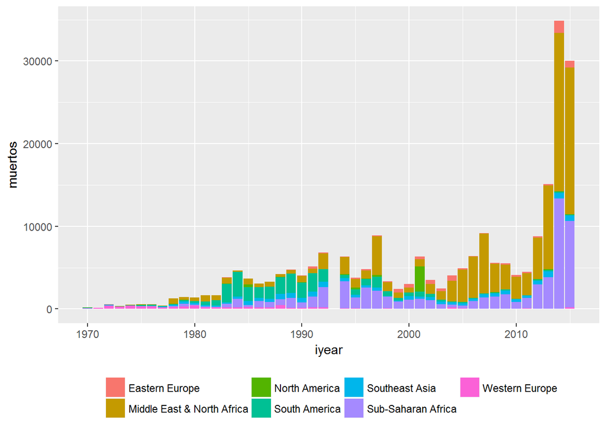

A modo de curiosidad estos han sido los ataques con mas muertos

```
##                          country_txt  nkill iyear
##  1:                             Iraq 1500.0  2014
##  2:                    United States 1381.5  2001
##  3:                    United States 1381.5  2001
##  4:                           Rwanda 1180.0  1994
##  5:                             Iraq  670.0  2014
##  6:                            Nepal  518.0  2004
##  7:                            Syria  517.0  2014
##  8:                             Iraq  500.0  2014
##  9:                             Iran  422.0  1978
## 10: Democratic Republic of the Congo  400.0  2009
```

[interactive chart not shown]

Y aquí se pueden ver los atentados mas grandes por año.

[interactive chart not shown]